# Return Home

View Code on Github

# Top Billboard Music Artist YouTube channels Analysis

## 1 Taylor Swift

is an American singer-songwriter. Her songwriting, artistry, and entrepreneurship have influenced the music industry and popular culture

## 2 Morgan Wallen

is an American country music singer and songwriter. He competed in the sixth season of The Voice, originally as a member of Usher's team, but later as a member of Adam Levine's team

## 3 Drake

is a Canadian rapper, singer, songwriter, and actor. An influential figure in contemporary popular music, Drake has been credited with popularizing singing and R&B sensibilities in hip hop artists

## 4 Chris Brown

American singer, songwriter, dancer, and actor. He's regarded as one of the most prominent artists in R&B music, being credited as an evolver of the genre, and often being referred to by contemporaries

## 5 Usher

is an American singer, songwriter, and dancer. He is widely recognized as an influential figure in contemporary R&B

## 6 Beyonce

is an American singer, songwriter and businesswoman. Dubbed as "Queen Bey" and a prominent cultural figure of the 21st century, she has been recognized for her artistry and performances, with Rolling Stone naming her one of the greatest vocalists of all time

## 7 Rihanna

is a Barbadian singer, businesswoman, actress, and songwriter. She is widely regarded as one of the most prominent singers of the 21st century

## 8 Eminem

He is credited with popularizing hip hop in Middle America and is often regarded as one of the greatest rappers of all time.

## 9 Tupac

was an American rapper. He is widely considered one of the most influential and successful rappers of all time. Shakur is among the best-selling music artists, having sold more than 75 million records worldwide

## 10 Adele

She is known for her mezzo-soprano vocals and sentimental songwriting. Adele has received numerous accolades including 16 Grammy Awards, 12 Brit Awards, an Academy Award

## 11 Michael Jackson

merican singer, songwriter, dancer, and philanthropist. Known as the "King of Pop", he is regarded as one of the most significant cultural figures of the 20th century

```python
# lets import libraries
from googleapiclient.discovery import build
import pandas as pd
import seaborn as sns
import matplotlib.pyplot as plt
```

## 1 Taylor Swift

```python
#  Function to get Taylor Swift Youtube channel statistics

api_key = 'AIzaSyB24Kop04L1GlTgRCm1XtQ4KB2a4gaBOwA'
Taylor_Swift_channel_id = ['UCqECaJ8Gagnn7YCbPEzWH6g' # Taylor Swift

              ]
youtube = build('youtube','v3',developerKey = api_key)

from googleapiclient.errors import HttpError

def get_channel_stats(youtube, Taylor_Swift_channel_id):
    all_data = []
    try:
        request = youtube.channels().list(
            part='snippet,contentDetails,statistics',
            id=','.join(Taylor_Swift_channel_id)
        )
        response = request.execute()

        for item in response.get('items', []):
            snippet = item.get('snippet', {})
            statistics = item.get('statistics', {})

            data = {
                'Channel_name': snippet.get('title', ''),
                'Subscribers': statistics.get('subscriberCount', ''),
                'Views': statistics.get('viewCount', ''),
                'Total_videos': statistics.get('videoCount', '')
            }

            all_data.append(data)

    except HttpError as e:
        print(f"HTTP error occurred: {e}")
        print(f"Request URL: {e.resp.request.url}")
        print(f"Request body: {e.resp.request.body}")

    return all_data
```

```python
get_channel_stats(youtube, Taylor_Swift_channel_id)
```

```
[{'Channel_name': 'Taylor Swift',
  'Subscribers': '56100000',
  'Views': '33022526691',
  'Total_videos': '225'}]
```

```python
channel_statistics = get_channel_stats(youtube, Taylor_Swift_channel_id)
```

```python
Taylor_Swift_channel_data =pd.DataFrame(channel_statistics)
```

```python
Taylor_Swift_channel_data
```

|  | Channel_name | Subscribers | Views | Total_videos |
| --- | --- | --- | --- | --- |
| 0 | Taylor Swift | 56100000 | 33022526691 | 225 |

## 2 Morgan Wallen

```python
#  Function to get Morgan Wallent Youtube channel statistics

api_key = 'AIzaSyB24Kop04L1GlTgRCm1XtQ4KB2a4gaBOwA'
Morgan_Wallent_channel_id = ['UCzIyoPv6j1MAZpDHKLGP_eA' # Morgan Wallen

              ]
youtube = build('youtube','v3',developerKey = api_key)

from googleapiclient.errors import HttpError

def get_channel_stats(youtube, Morgan_Wallent_channel_id):
    all_data = []
    try:
        request = youtube.channels().list(
            part='snippet,contentDetails,statistics',
            id=','.join(Morgan_Wallent_channel_id)
        )
        response = request.execute()

        for item in response.get('items', []):
            snippet = item.get('snippet', {})
            statistics = item.get('statistics', {})

            data = {
                'Channel_name': snippet.get('title', ''),
                'Subscribers': statistics.get('subscriberCount', ''),
                'Views': statistics.get('viewCount', ''),
                'Total_videos': statistics.get('videoCount', '')
            }

            all_data.append(data)

    except HttpError as e:
        print(f"HTTP error occurred: {e}")
        print(f"Request URL: {e.resp.request.url}")
        print(f"Request body: {e.resp.request.body}")

    return all_data
```

```python
get_channel_stats(youtube, Morgan_Wallent_channel_id)
```

```
[{'Channel_name': 'Morgan Wallen',
  'Subscribers': '2640000',
  'Views': '4210976804',
  'Total_videos': '85'}]
```

```python
Morgan_Wallent_channel_data =pd.DataFrame(channel_statistics)
```

```python
Morgan_Wallent_channel_data
```

[output not shown]

## 3 Drake

```python
#  Function to get Taylor Drake Youtube channel statistics

api_key = 'AIzaSyB24Kop04L1GlTgRCm1XtQ4KB2a4gaBOwA'
Drake_channel_id = ['UCByOQJjav0CUDwxCk-jVNRQ' # Drake

              ]
youtube = build('youtube','v3',developerKey = api_key)

from googleapiclient.errors import HttpError

def get_channel_stats(youtube, Drake_channel_id):
    all_data = []
    try:
        request = youtube.channels().list(
            part='snippet,contentDetails,statistics',
            id=','.join(Drake_channel_id)
        )
        response = request.execute()

        for item in response.get('items', []):
            snippet = item.get('snippet', {})
            statistics = item.get('statistics', {})

            data = {
                'Channel_name': snippet.get('title', ''),
                'Subscribers': statistics.get('subscriberCount', ''),
                'Views': statistics.get('viewCount', ''),
                'Total_videos': statistics.get('videoCount', '')
            }

            all_data.append(data)

    except HttpError as e:
        print(f"HTTP error occurred: {e}")
        print(f"Request URL: {e.resp.request.url}")
        print(f"Request body: {e.resp.request.body}")

    return all_data
```

```python
get_channel_stats(youtube, Drake_channel_id)
```

```
[{'Channel_name': 'Drake',
  'Subscribers': '29200000',
  'Views': '16817445498',
  'Total_videos': '62'}]
```

```python
channel_statistics = get_channel_stats(youtube, Drake_channel_id)
```

```python
Drake_channel_data =pd.DataFrame(channel_statistics)
```

```python
Drake_channel_data
```

|  | Channel_name | Subscribers | Views | Total_videos |
| --- | --- | --- | --- | --- |
| 0 | Drake | 29200000 | 16817445498 | 62 |

## 4 Chris Brown

```python
#  Function to get Taylor Swift Youtube channel statistics

api_key = 'AIzaSyB24Kop04L1GlTgRCm1XtQ4KB2a4gaBOwA'
Chris_Brown_channel_id = ['UCcYrdFJF7hmPXRNaWdrko4w' # Chris Brown

              ]
youtube = build('youtube','v3',developerKey = api_key)

from googleapiclient.errors import HttpError

def get_channel_stats(youtube, Chris_Brown_channel_id):
    all_data = []
    try:
        request = youtube.channels().list(
            part='snippet,contentDetails,statistics',
            id=','.join(Chris_Brown_channel_id)
        )
        response = request.execute()

        for item in response.get('items', []):
            snippet = item.get('snippet', {})
            statistics = item.get('statistics', {})

            data = {
                'Channel_name': snippet.get('title', ''),
                'Subscribers': statistics.get('subscriberCount', ''),
                'Views': statistics.get('viewCount', ''),
                'Total_videos': statistics.get('videoCount', '')
            }

            all_data.append(data)

    except HttpError as e:
        print(f"HTTP error occurred: {e}")
        print(f"Request URL: {e.resp.request.url}")
        print(f"Request body: {e.resp.request.body}")

    return all_data
```

```python
get_channel_stats(youtube, Chris_Brown_channel_id)
```

```
[{'Channel_name': 'Chris Brown',
  'Subscribers': '26000000',
  'Views': '16519789134',
  'Total_videos': '42'}]
```

```python
channel_statistics = get_channel_stats(youtube, Chris_Brown_channel_id)
```

```python
Chris_Brown_channel_data =pd.DataFrame(channel_statistics)
```

```python
Chris_Brown_channel_data
```

|  | Channel_name | Subscribers | Views | Total_videos |
| --- | --- | --- | --- | --- |
| 0 | Chris Brown | 26000000 | 16519789134 | 42 |

## 5 Usher

```python
#  Function to get Usher Youtube channel statistics

api_key = 'AIzaSyB24Kop04L1GlTgRCm1XtQ4KB2a4gaBOwA'
Usher_channel_id = ['UCaNrhBiXsXIM2epDl_kEzgQ' # Usher

              ]
youtube = build('youtube','v3',developerKey = api_key)

from googleapiclient.errors import HttpError

def get_channel_stats(youtube, Usher_channel_id):
    all_data = []
    try:
        request = youtube.channels().list(
            part='snippet,contentDetails,statistics',
            id=','.join(Usher_channel_id)
        )
        response = request.execute()

        for item in response.get('items', []):
            snippet = item.get('snippet', {})
            statistics = item.get('statistics', {})

            data = {
                'Channel_name': snippet.get('title', ''),
                'Subscribers': statistics.get('subscriberCount', ''),
                'Views': statistics.get('viewCount', ''),
                'Total_videos': statistics.get('videoCount', '')
            }

            all_data.append(data)

    except HttpError as e:
        print(f"HTTP error occurred: {e}")
        print(f"Request URL: {e.resp.request.url}")
        print(f"Request body: {e.resp.request.body}")

    return all_data
```

```python
get_channel_stats(youtube, Usher_channel_id)
```

```
[{'Channel_name': 'Usher',
  'Subscribers': '7860000',
  'Views': '6503106474',
  'Total_videos': '195'}]
```

```python
channel_statistics = get_channel_stats(youtube, Usher_channel_id)
```

```python
Usher_channel_data =pd.DataFrame(channel_statistics)
```

```python
Usher_channel_data
```

|  | Channel_name | Subscribers | Views | Total_videos |
| --- | --- | --- | --- | --- |
| 0 | Usher | 7860000 | 6503106474 | 195 |

## 6 Beyonce

```python
#  Function to get Beyoncet Youtube channel statistics

api_key = 'AIzaSyB24Kop04L1GlTgRCm1XtQ4KB2a4gaBOwA'
Beyonce_channel_id = ['UCuHzBCaKmtaLcRAOoazhCPA' # Beyonce

              ]
youtube = build('youtube','v3',developerKey = api_key)

from googleapiclient.errors import HttpError

def get_channel_stats(youtube, Beyonce_channel_id ):
    all_data = []
    try:
        request = youtube.channels().list(
            part='snippet,contentDetails,statistics',
            id=','.join(Beyonce_channel_id )
        )
        response = request.execute()

        for item in response.get('items', []):
            snippet = item.get('snippet', {})
            statistics = item.get('statistics', {})

            data = {
                'Channel_name': snippet.get('title', ''),
                'Subscribers': statistics.get('subscriberCount', ''),
                'Views': statistics.get('viewCount', ''),
                'Total_videos': statistics.get('videoCount', '')
            }

            all_data.append(data)

    except HttpError as e:
        print(f"HTTP error occurred: {e}")
        print(f"Request URL: {e.resp.request.url}")
        print(f"Request body: {e.resp.request.body}")

    return all_data
```

```python
get_channel_stats(youtube, Beyonce_channel_id)
```

```
[{'Channel_name': 'Beyoncé',
  'Subscribers': '26600000',
  'Views': '18021652519',
  'Total_videos': '245'}]
```

```python
channel_statistics = get_channel_stats(youtube, Beyonce_channel_id)
```

```python
Beyonce_channel_data =pd.DataFrame(channel_statistics)
```

```python
Beyonce_channel_data
```

|  | Channel_name | Subscribers | Views | Total_videos |
| --- | --- | --- | --- | --- |
| 0 | Beyoncé | 26600000 | 18021652519 | 245 |

## 7 Rihana

```python
#  Function to get Beyonce Youtube channel statistics
#  Function to get Rihanna  Youtube channel statistics

api_key = 'AIzaSyB24Kop04L1GlTgRCm1XtQ4KB2a4gaBOwA'
Rihanna_channel_id = ['UCcgqSM4YEo5vVQpqwN-MaNw' # Rihanna

              ]
youtube = build('youtube','v3',developerKey = api_key)

from googleapiclient.errors import HttpError

def get_channel_stats(youtube, Rihanna_channel_id):
    all_data = []
    try:
        request = youtube.channels().list(
            part='snippet,contentDetails,statistics',
            id=','.join(Rihanna_channel_id)
        )
        response = request.execute()

        for item in response.get('items', []):
            snippet = item.get('snippet', {})
            statistics = item.get('statistics', {})

            data = {
                'Channel_name': snippet.get('title', ''),
                'Subscribers': statistics.get('subscriberCount', ''),
                'Views': statistics.get('viewCount', ''),
                'Total_videos': statistics.get('videoCount', '')
            }

            all_data.append(data)

    except HttpError as e:
        print(f"HTTP error occurred: {e}")
        print(f"Request URL: {e.resp.request.url}")
        print(f"Request body: {e.resp.request.body}")

    return all_data
```

```python
get_channel_stats(youtube, Rihanna_channel_id )
```

[output not shown]

```python
channel_statistics = get_channel_stats(youtube, Rihanna_channel_id )
```

```python
Rihanna_channel_data =pd.DataFrame(channel_statistics)
```

```python
Rihanna_channel_data
```

|  | Channel_name | Subscribers | Views | Total_videos |
| --- | --- | --- | --- | --- |
| 0 | Rihanna | 42600000 | 23606574806 | 85 |

## 8 Eminem

```python
#  Function to get Eminem Youtube channel statistics

api_key = 'AIzaSyB24Kop04L1GlTgRCm1XtQ4KB2a4gaBOwA'
Eminem_channel_id = ['UCfM3zsQsOnfWNUppiycmBuw' # Eminem

              ]
youtube = build('youtube','v3',developerKey = api_key)

from googleapiclient.errors import HttpError

def get_channel_stats(youtube, Eminem_channel_id):
    all_data = []
    try:
        request = youtube.channels().list(
            part='snippet,contentDetails,statistics',
            id=','.join(Eminem_channel_id)
        )
        response = request.execute()

        for item in response.get('items', []):
            snippet = item.get('snippet', {})
            statistics = item.get('statistics', {})

            data = {
                'Channel_name': snippet.get('title', ''),
                'Subscribers': statistics.get('subscriberCount', ''),
                'Views': statistics.get('viewCount', ''),
                'Total_videos': statistics.get('videoCount', '')
            }

            all_data.append(data)

    except HttpError as e:
        print(f"HTTP error occurred: {e}")
        print(f"Request URL: {e.resp.request.url}")
        print(f"Request body: {e.resp.request.body}")

    return all_data
```

```python
get_channel_stats(youtube, Eminem_channel_id)
```

```
[{'Channel_name': 'EminemMusic',
  'Subscribers': '58700000',
  'Views': '28552490434',
  'Total_videos': '159'}]
```

```python
channel_statistics = get_channel_stats(youtube, Eminem_channel_id)
```

```python
Eminem_channel_data =pd.DataFrame(channel_statistics)
```

```python
Eminem_channel_data
```

|  | Channel_name | Subscribers | Views | Total_videos |
| --- | --- | --- | --- | --- |
| 0 | EminemMusic | 58700000 | 28552490434 | 159 |

## 9 Tupac

```python
#  Function to get Tupac Youtube channel statistics

api_key = 'AIzaSyB24Kop04L1GlTgRCm1XtQ4KB2a4gaBOwA'
Tupac_channel_id = ['UCMIdeeBjp_60Jv7ROpRxK6Q' # Tupac

              ]
youtube = build('youtube','v3',developerKey = api_key)

from googleapiclient.errors import HttpError

def get_channel_stats(youtube, Tupac_channel_id):
    all_data = []
    try:
        request = youtube.channels().list(
            part='snippet,contentDetails,statistics',
            id=','.join(Tupac_channel_id)
        )
        response = request.execute()

        for item in response.get('items', []):
            snippet = item.get('snippet', {})
            statistics = item.get('statistics', {})

            data = {
                'Channel_name': snippet.get('title', ''),
                'Subscribers': statistics.get('subscriberCount', ''),
                'Views': statistics.get('viewCount', ''),
                'Total_videos': statistics.get('videoCount', '')
            }

            all_data.append(data)

    except HttpError as e:
        print(f"HTTP error occurred: {e}")
        print(f"Request URL: {e.resp.request.url}")
        print(f"Request body: {e.resp.request.body}")

    return all_data
```

```python
get_channel_stats(youtube, Tupac_channel_id)
```

```
[{'Channel_name': '2Pac',
  'Subscribers': '7450000',
  'Views': '3361858489',
  'Total_videos': '33'}]
```

```python
Tupac_channel_statistics = get_channel_stats(youtube, Tupac_channel_id)
```

```python
Tupac_channel_data =pd.DataFrame(Tupac_channel_statistics)
```

```python
Tupac_channel_data
```

|  | Channel_name | Subscribers | Views | Total_videos |
| --- | --- | --- | --- | --- |
| 0 | 2Pac | 7450000 | 3361858489 | 33 |

## 10 Adele

```python
#  Function to get  Adele Youtube channel statistics

api_key = 'AIzaSyB24Kop04L1GlTgRCm1XtQ4KB2a4gaBOwA'
Adele_channel_id = ['UCsRM0YB_dabtEPGPTKo-gcw' # Adele

              ]
youtube = build('youtube','v3',developerKey = api_key)

from googleapiclient.errors import HttpError

def get_channel_stats(youtube, Adele_channel_id):
    all_data = []
    try:
        request = youtube.channels().list(
            part='snippet,contentDetails,statistics',
            id=','.join(Adele_channel_id)
        )
        response = request.execute()

        for item in response.get('items', []):
            snippet = item.get('snippet', {})
            statistics = item.get('statistics', {})

            data = {
                'Channel_name': snippet.get('title', ''),
                'Subscribers': statistics.get('subscriberCount', ''),
                'Views': statistics.get('viewCount', ''),
                'Total_videos': statistics.get('videoCount', '')
            }

            all_data.append(data)

    except HttpError as e:
        print(f"HTTP error occurred: {e}")
        print(f"Request URL: {e.resp.request.url}")
        print(f"Request body: {e.resp.request.body}")

    return all_data
```

```python
get_channel_stats(youtube, Adele_channel_id)
```

```
[{'Channel_name': 'Adele',
  'Subscribers': '30900000',
  'Views': '15128870668',
  'Total_videos': '15'}]
```

```python
channel_statistics = get_channel_stats(youtube,  Adele_channel_id)
```

```python
Adele_channel_data =pd.DataFrame(channel_statistics)
```

```python
Adele_channel_data
```

|  | Channel_name | Subscribers | Views | Total_videos |
| --- | --- | --- | --- | --- |
| 0 | Adele | 30900000 | 15128870668 | 15 |

## 11 Michael Jackson

```python
#  Function to get  Michael Jackson Youtube channel statistics

api_key = 'AIzaSyB24Kop04L1GlTgRCm1XtQ4KB2a4gaBOwA'
Michael_Jackson_channel_id = ['UC5OrDvL9DscpcAstz7JnQGA' # Michael Jackson

              ]
youtube = build('youtube','v3',developerKey = api_key)

from googleapiclient.errors import HttpError

def get_channel_stats(youtube, Michael_Jackson_channel_id):
    all_data = []
    try:
        request = youtube.channels().list(
            part='snippet,contentDetails,statistics',
            id=','.join(Michael_Jackson_channel_id)
        )
        response = request.execute()

        for item in response.get('items', []):
            snippet = item.get('snippet', {})
            statistics = item.get('statistics', {})

            data = {
                'Channel_name': snippet.get('title', ''),
                'Subscribers': statistics.get('subscriberCount', ''),
                'Views': statistics.get('viewCount', ''),
                'Total_videos': statistics.get('videoCount', '')
            }

            all_data.append(data)

    except HttpError as e:
        print(f"HTTP error occurred: {e}")
        print(f"Request URL: {e.resp.request.url}")
        print(f"Request body: {e.resp.request.body}")

    return all_data
```

```python
get_channel_stats(youtube, Michael_Jackson_channel_id)
```

```
[{'Channel_name': 'Michael Jackson',
  'Subscribers': '29500000',
  'Views': '15397624489',
  'Total_videos': '17'}]
```

```python
channel_statistics = get_channel_stats(youtube, Michael_Jackson_channel_id)
```

```python
Michael_Jackson_channel_data =pd.DataFrame(channel_statistics)
```

```python
Michael_Jackson_channel_data
```

|  | Channel_name | Subscribers | Views | Total_videos |
| --- | --- | --- | --- | --- |
| 0 | Michael Jackson | 29500000 | 15397624489 | 17 |

```python
# Combine DataFrames using concat
combined_billboard_music_channels_df = pd.concat([
                               Taylor_Swift_channel_data ,
                                       Morgan_Wallent_channel_data,
                                       Drake_channel_data,
                                       Chris_Brown_channel_data,
                                       Usher_channel_data,
                                         Beyonce_channel_data,
                                           Rihanna_channel_data,
                                          Eminem_channel_data,

                                        Tupac_channel_data,

                                   Adele_channel_data,
    Michael_Jackson_channel_data,
                                      ], ignore_index=True)

# Display the result
print(combined_billboard_music_channels_df)
```

[output not shown]

```python
# lets have  a look at the datatypes
combined_billboard_music_channels_df.info()
```

```
<class 'pandas.core.frame.DataFrame'>
RangeIndex: 11 entries, 0 to 10
Data columns (total 4 columns):
 #   Column        Non-Null Count  Dtype
---  ------        --------------  -----
 0   Channel_name  11 non-null     object
 1   Subscribers   11 non-null     object
 2   Views         11 non-null     object
 3   Total_videos  11 non-null     object
dtypes: object(4)
memory usage: 484.0+ bytes
```

```python
# lets change the datatypes to perform  visualisations
combined_billboard_music_channels_df['Subscribers'] = pd.to_numeric(combined_billboard_music_channels_df['Subscribers'])
combined_billboard_music_channels_df['Views'] = pd.to_numeric(combined_billboard_music_channels_df['Views'])
combined_billboard_music_channels_df['Total_videos'] = pd.to_numeric(combined_billboard_music_channels_df['Total_videos'])
# letsconirm if the datatypes has changed
combined_billboard_music_channels_df.info()
```

```
<class 'pandas.core.frame.DataFrame'>
RangeIndex: 11 entries, 0 to 10
Data columns (total 4 columns):
 #   Column        Non-Null Count  Dtype
---  ------        --------------  -----
 0   Channel_name  11 non-null     object
 1   Subscribers   11 non-null     int64
 2   Views         11 non-null     int64
 3   Total_videos  11 non-null     int64
dtypes: int64(3), object(1)
memory usage: 484.0+ bytes
```

```python
combined_billboard_music_channels_df
```

|  | Channel_name | Subscribers | Views | Total_videos |
| --- | --- | --- | --- | --- |
| 0 | Taylor Swift | 56100000 | 33022526691 | 225 |
| 1 | Adele | 30900000 | 15128870668 | 15 |
| 2 | Drake | 29200000 | 16817445498 | 62 |
| 3 | Chris Brown | 26000000 | 16519789134 | 42 |
| 4 | Usher | 7860000 | 6503106474 | 195 |
| 5 | Beyoncé | 26600000 | 18021652519 | 245 |
| 6 | Rihanna | 42600000 | 23606574806 | 85 |
| 7 | EminemMusic | 58700000 | 28552490434 | 159 |
| 8 | 2Pac | 7450000 | 3361858489 | 33 |
| 9 | Adele | 30900000 | 15128870668 | 15 |
| 10 | Michael Jackson | 29500000 | 15397624489 | 17 |

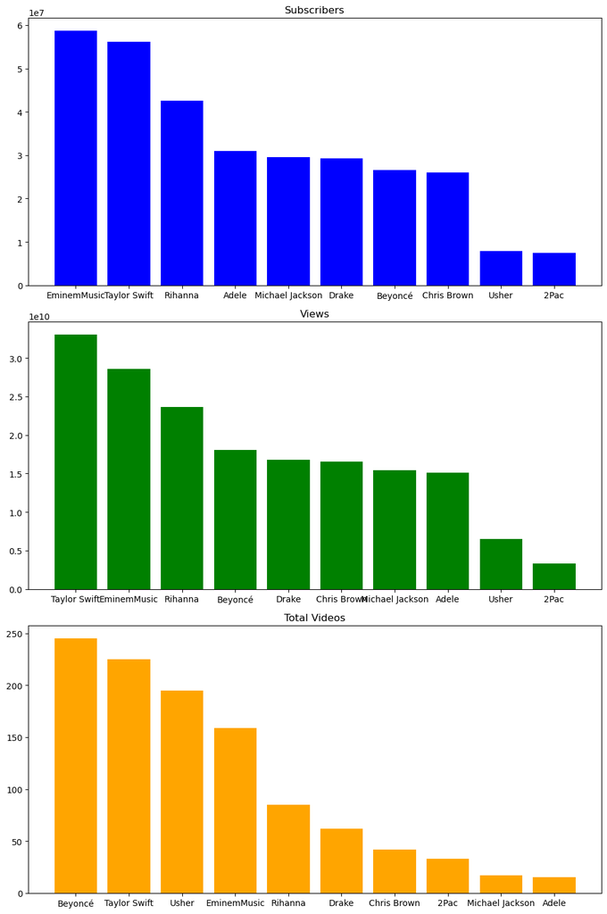

```python
# Sort the DataFrame by 'Subscribers' in descending order
combined_billboard_music_channels_df_subscribers_sorted = combined_billboard_music_channels_df.sort_values(by='Subscribers', ascending=False)

# Plotting Subscribers in descending order
fig, axes = plt.subplots(nrows=3, ncols=1, figsize=(10, 15))

axes[0].bar(combined_billboard_music_channels_df_subscribers_sorted['Channel_name'], combined_billboard_music_channels_df_subscribers_sorted['Subscribers'], color='blue')
axes[0].set_title('Subscribers')

# Sort the DataFrame by 'Views' in descending order
combined_billboard_music_channels_df_views_sorted = combined_billboard_music_channels_df.sort_values(by='Views', ascending=False)

# Plotting Views in descending order
axes[1].bar(combined_billboard_music_channels_df_views_sorted['Channel_name'], combined_billboard_music_channels_df_views_sorted['Views'], color='green')
axes[1].set_title('Views')

# Sort the DataFrame by 'Total_videos' in descending order
combined_billboard_music_channels_df_total_videos_sorted = combined_billboard_music_channels_df.sort_values(by='Total_videos', ascending=False)

# Plotting Total Videos in descending order
axes[2].bar(combined_billboard_music_channels_df_total_videos_sorted['Channel_name'], combined_billboard_music_channels_df_total_videos_sorted['Total_videos'], color='orange')
axes[2].set_title('Total Videos')

# Adjust layout for better visibility
plt.tight_layout()

# Show the plot
plt.show()
```